# Build Online Perceptron Classifier from Scratch for Restaurant Review Classification with N-gram Model

## I INTRODUCTION

This project aims to build an Online Perceptron classifier in Python from scratch for a binary restaurant review classification under a real-world scenario: efficiently train the classifier with one million restaurant reviews and ratings, then make highly accurate prediction on 320,122 test examples to find out whether or not the ratings of restaurants are at least 4 out of 5 stars based on customers' reviews.

As the first step of the classifier development, a n-gram model is used to represent the restaurant reviews, that is, each word or each group of words appears in the training dataset is treated as a feature, and its value for a specific document in the corpus is the counts of its occurrences. When setting n = 1, 2, or 3, I get the Unigram, Bigram or Trigram correspondingly, which, in terms of the training set, are respectively a 1,000,000 by 207,393, 1,000,000 by 6,680,976, or 1,000,000 by 32,145,597 sparse matrix after affine expansion. The Unigram only makes use of the information reflected by the term frequency of each individual word, while the Bigram or Trigram exploits the message revealed by n (n >= 2) adjacent words, more like human speech is supposed to be. Therefore, in this project, I adopt the Bigram model to train and test our self-developed Online Perceptron classifier. To deal with the challenges posted by the high dimensional Bigram feature matrix, I further explore the Mini-Batch online learning and the Chi-square test feature selection to achieve a good balance between the computational efficiency and the prediction accuracy.

This report is organized as follows: Section II introduces an implementation of the basic Online Perceptron algorithm, while Section III and IV respectively discuss the Mini-Batch Online Perceptron and the Online Perceptron with Feature Selection by Chi-sqaure test. A short summary and comparison can be found in Section V.

## II BASIC IMPLEMENTATION OF ONLINE PERCEPTRON ALGORITHM

Online Perceptron algorithm performs stochastic gradient descent, which updates the weight vector immediately after every single wrong prediction during a pass over the randomly shuffled training dataset. The performance of Online Perceptron is sensitive to the order in which the training examples are fed. To guarantee the prediction accuracy, I traverse through the training data twice to train the classifier, and further carry out the online-to-batch conversion in the second pass by taking the average of the 1,000,001 weight vectors.

As shown from Line 17 to Line 61 in the following block, the implementation of Online Perceptron is pretty straightforward. However, its training speed turns out to be terribly slow in our case: on a computer with 2.7 GHz Intel Core i7 and 12 GB RAM, it took over 4 hours to obtain the final classifier of which the training error rate is 4.97% and the test error rate is 10.06%. The root cause of this time-consuming training process arises from the need to loop through the 1,000,000 by 6,680,976 feature matrix twice to execute operations required by Online Perceptron algorithm.

```python
import time
import pandas as pd
import numpy as np

from scipy.sparse import csr_matrix, hstack

from sklearn.feature_extraction.text import CountVectorizer
from sklearn.feature_extraction.text import TfidfVectorizer
from sklearn.feature_selection import SelectKBest, chi2

import matplotlib.pyplot as plt

%matplotlib inline

#==================================================================================
#==================================================================================
def onlinePerceptron(X, Y):

    YX = X.multiply(Y)
    YX = YX.tocsr()

    totalExs = X.shape[0]
    totalFeats = X.shape[1]
    w = np.zeros((1, totalFeats), dtype=np.float)

    for i in range(totalExs):
        wx = X[i].dot(w.T)

        if Y[i] * wx <= 0:
            w = w + YX[i]

    return w

#==================================================================================
#==================================================================================
def aveOnlinePerceptron(X, Y, w):
    u0 = w
    u = w
    c = 1

    totalExs = X.shape[0]
    rowIdx = np.arange(totalExs)
    np.random.shuffle(rowIdx)
    X = X[rowIdx, :]
    Y = Y[rowIdx, :]

    YX = X.multiply(Y)
    YX = YX.tocsr()

    for i in range(totalExs):
        wx = X[i].dot(w.T)

        if Y[i] * wx <= 0:
            w = w + YX[i]
            u = u + c * YX[i]

        c = c + 1

    w = u0/c + w - 1/c * u

    return w

#==================================================================================
#==================================================================================
def getErrorRate(X, Y, wFinal):

    totalEx = X.shape[0]
    preds = np.zeros((totalEx, 1))

    preds = X.dot(wFinal.T)
    preds[preds <= 0] = -1
    preds[preds > 0] = 1

    errors = np.sum(Y != preds)
    errorRate = float(errors / totalEx)

    return errorRate

#==================================================================================
#==================================================================================
```

## III Mini-Batch ONLINE PERCEPTRON

One way to speed up Online Perceptron when handling high-dimensional data is to take advantage of matrix operations instead of simply looping through the training examples one by one. In other words, split the one million training data into M small batches so that each batch only contains N training examples (M * N = 1,000,000). Then for each mini-batch, apply matrix operations to calculate the dot product and update the weight vectors when needed.

```python
def miniBatchOnlinePerceptron(X, Y, N, M):

    YX = X.multiply(Y)
    YX = YX.tocsr()

    totalFeats = X.shape[1]
    w = np.zeros((1, totalFeats), dtype=np.float)

    for i in range(M):
        x = X[i*N:(i+1)*N, :]
        y = Y[i*N:(i+1)*N, :]
        yx = YX[i*N:(i+1)*N, :]

        wx = x.dot(w.T)
        ywx = np.multiply(y, wx)
        idx = np.where(ywx <= 0.0)
        idx = idx[0]

        if(idx.shape[0] > 0):
            yx = yx[idx]
            yxSum = yx.sum(axis=0)
            yxAve = np.multiply(yxSum, 1/N)

            w = w + yxAve

    return w

#==================================================================================
#==================================================================================
def aveMiniBatchOnlinePerceptron(X, Y, w, N, M):
    u0 = w
    u = w
    c = 1

    totalExs = X.shape[0]
    totalFeats = X.shape[1]

    rowIdx = np.arange(totalExs)
    np.random.shuffle(rowIdx)
    X = X[rowIdx, :]
    Y = Y[rowIdx, :]

    YX = X.multiply(Y)
    YX = YX.tocsr()

    for i in range(M):
        x = X[i*N:(i+1)*N, :]
        y = Y[i*N:(i+1)*N, :]
        yx = YX[i*N:(i+1)*N, :]

        wx = x.dot(w.T)
        ywx = np.multiply(y, wx)
        idx = np.where(ywx <= 0.0)
        idx = idx[0]

        if(idx.shape[0] > 0):
            yx = yx[idx]
            yxSum = yx.sum(axis=0)
            yxAve = np.multiply(yxSum, 1/N)

            w = w + yxAve
            u = u + c * yxAve

        c = c + 1

    w = u0/c + w - 1/c * u

    return w

#==================================================================================
#==================================================================================
```

This Mini-Batch variation of Online Perceptron implementation has been proven to be significantly faster than the "naive" one. For instance, when setting 1000 training examples per batch, it only took about 7 miniutes to obtain the final weight vector, meanwhile, the test error rate is just 9.48%, which is even better than that got from the original Online Perceptron classifier. Varying the size of a mini-batch, the training time and error rates also change. In general, the bigger the mini-batch, the shorter the training time and the slightly higher the error rates.

In addition, checking the feature names which correspond to the top and the bottom 50 weights, it is easy to see that both groups are indeed a good indicator of their respective classes. In other words, when a customer review contains any words in the group of the top 50 feature names, he/she is very likely to rate the restaurant as 4 stars or above (correspondingly to lable +1), and vice versa.

```python
#==================================================================================
#==================================================================================
def main(opt='mini-batch'):

    start0 = time.time()

    trainingDF = pd.read_csv("reviews_tr.csv")
    trainingDF['label'] = trainingDF['label'].replace(0, -1)

    print ("Running time to load training dataset: {:.2f} seconds\n".format(time.time() - start0))

#==================================================================================
#==================================================================================
    start1 = time.time()

    textTr = trainingDF['text'].tolist()
    labelTr = trainingDF['label'].tolist()

    vectorizer2 = CountVectorizer(input = 'content', ngram_range = (2, 2))
    vectorizer2 = vectorizer2.fit(textTr)

    feature_names = vectorizer2.get_feature_names()
    bigramTr = vectorizer2.transform(textTr)

    labelTr = np.asarray(labelTr)
    labelTr = np.reshape(labelTr, (bigramTr.shape[0], 1))

    if (opt == 'featureSelection'):
        bigramTr, ch2_selector = featureSelector4Training(bigramTr, labelTr, feature_names)

    biasTr = np.ones((bigramTr.shape[0], 1))
    bigramTr = hstack([biasTr, bigramTr])
    bigramTr = bigramTr.tocsr()

    if (opt == 'featureSelection'):
        print("bigramTr.shape with selected features after affine expansion: {}".format(bigramTr.shape))
        print("Running time to get bigramTr with selected features: {:.2f} minutes\n".format((time.time() - start1)/60.0 ))

    else:
        print("bigramTr.shape after affine expansion: {}".format(bigramTr.shape))
        print("Running time to get bigramTr: {:.2f} minutes\n".format((time.time() - start1)/60.0 ))

#==================================================================================
#==================================================================================
    start3 = time.time()

    if (opt == 'featureSelection'):
        weight = onlinePerceptron(bigramTr, labelTr)

    else:
        N = 1000
        M = int(bigramTr.shape[0] / N)
        print("Number of training examples per batch: {}".format(N))
        print("Total mini-batches over the training dataset: {}\n".format(M))

        weight = miniBatchOnlinePerceptron(bigramTr, labelTr, N, M)

    print ("Running time to get the weight after the 1st pass: {:.2f} minutes".format((time.time() - start3)/60.0))

    #==================================================================================
    start4 = time.time()

    if (opt == 'featureSelection'):
        weightFinal = aveOnlinePerceptron(bigramTr, labelTr, weight)

    else:
        weightFinal = aveMiniBatchOnlinePerceptron(bigramTr, labelTr, weight, N, M)

    print ("Running time to get the averaged weightFinal after the 2nd pass: {:.2f} minutes\n".format((time.time() - start4)/60.0))

#==================================================================================
#==================================================================================
    wf = np.array(weightFinal).reshape(weightFinal.shape[1],)
    wf_idx_top50 = wf.argsort()[-50:][::-1]
    wf_idx_bot50 = wf.argsort()[:50]

    weightFinal_top50 = wf[wf_idx_top50]
    weightFinal_bot50 = wf[wf_idx_bot50]

    top50_wf_feature_names = []
    bot50_wf_feature_names = []
    for i in wf_idx_top50:
        top50_wf_feature_names.append(feature_names[i])

    for i in wf_idx_bot50:
        bot50_wf_feature_names.append(feature_names[i])

    print("Top 50 feature names with highest weightFinal:\n{}\n".format(top50_wf_feature_names))
    print("Bot 50 feature names with lowest weightFinal:\n{}\n".format(bot50_wf_feature_names))
#==================================================================================
#==================================================================================
    start5 = time.time()

    testDF = pd.read_csv("reviews_te.csv")
    testDF['label'] = testDF['label'].replace(0, -1)

    textTe = testDF['text'].tolist()
    labelTe = testDF['label'].tolist()

    bigramTe = vectorizer2.transform(textTe)

    if (opt == 'featureSelection'):
        bigramTe = featureSelector4Test(bigramTe, ch2_selector)

    biasTe = np.ones((bigramTe.shape[0], 1))
    bigramTe = hstack([biasTe, bigramTe])
    bigramTe = bigramTe.tocsr()

    labelTe = np.asarray(labelTe)
    labelTe = np.reshape(labelTe, (bigramTe.shape[0], 1))

    if (opt == 'featureSelection'):
        print("bigramTe.shape with selected features after affine expansion: {}".format(bigramTe.shape))
        print("Running time to get bigramTe with selected features: {:.2f} minutes\n".format((time.time() - start1)/60.0 ))

    else:
        print("bigramTe.shape after affine expansion: {}".format(bigramTe.shape))
        print ("Running time to get bigramTe: {:.2f} minutes\n".format((time.time() - start5)/60.0 ))

#==================================================================================
#==================================================================================
    start6 = time.time()

    bigramTrainingErrRate = getErrorRate(bigramTr, labelTr, weightFinal)
    bigramTestErrRate = getErrorRate(bigramTe, labelTe, weightFinal)

    print ("bigramTrainingErrRate: {:.4f}".format(bigramTrainingErrRate))
    print ("bigramTestErrRate = {:.4f}".format(bigramTestErrRate))
    print ("Running time to get training & test error rates: {:.2f} seconds\n".format(time.time() - start6))

#==================================================================================
#==================================================================================
```

```python
if __name__ == "__main__":

    print("Mini-batch Online Perceptron Classification:\n")
    main()

#==================================================================================
#==================================================================================
```

```
Mini-batch Online Perceptron Classification:

Running time to load training dataset: 10.11 seconds

bigramTr.shape after affine expansion: (1000000, 6680976)
Running time to get bigramTr: 6.18 minutes

Number of training examples per batch: 1000
Total mini-batches over the training dataset: 1000

Running time to get the weight after the 1st pass: 2.93 minutes
Running time to get the averaged weightFinal after the 2nd pass: 4.15 minutes

Top 50 feature names with highest weightFinal:
['yurned for', 'not disappointing', 'yurm yurm', 'only yes', 'yermo california', 'five starskies', 'four start', 'not disappointed', 'can waite', 'be disappointediii', 'was fantastica', 'was outstandingly', 'was perfect1', 'back sooner', 'only negatives', 'was amazinggg', 'so glade', 'glad didn', 's…

Bot 50 feature names with lowest weightFinal:
['three starses', 'two start', 'the worsted', 'not worthed', 'food poisonings', 'very disappointedand', 'an okay', 'no flavorand', 'never against', 'very disappointingly', 'was terribles', 'so disappointing', 'was mediocrity', 'was awfull', 'not impresses', 'was horribly', 'very blandly', 'at bestha…

bigramTe.shape after affine expansion: (320122, 6680976)
Running time to get bigramTe: 0.97 minutes

bigramTrainingErrRate: 0.0731
bigramTestErrRate = 0.0948
Running time to get training & test error rates: 1.02 seconds
```

## IV ONLINE PERCEPTRON WITH FEATURE SELECTION BY CHI-SQUARE TEST

An alternative way to improve the computation efficiency of the original Online Perceptron is to reduce the dimensionality of the Bigram matrix by feature selection. The following code block shows how to use the sklearn SelectKBest class with a chi2 score function to do so.

```python
#==================================================================================
#==================================================================================
def featureSelector4Training(Xtrain, Ytrain, feature_names):

    ch2_selector = SelectKBest(chi2, k="all")
    ch2_selector = ch2_selector.fit(Xtrain, Ytrain)
    ch2_selector_scores = ch2_selector.scores_
    ch2_selector_pvalues = ch2_selector.pvalues_
    ch2_selector_scores_max = np.max(ch2_selector_scores)
    ch2_selector_scores_min = np.min(ch2_selector_scores)
    ch2_selector_pvalues_max = np.max(ch2_selector_pvalues)
    ch2_selector_pvalues_min = np.min(ch2_selector_pvalues)
    print("ch2_scores_max = {}\tch2_scores_min = {}".format(ch2_selector_scores_max, \
                                                                         ch2_selector_scores_min))
    print("ch2_pvalues_min = {}\t\t\tch2_pvalues_max = {}\n".format(ch2_selector_pvalues_min, \
                                                                         ch2_selector_pvalues_max))

    ch2_selector_scores_idx_top50 = ch2_selector_scores.argsort()[-50:][::-1]

    top50_feature_names = []
    for i in ch2_selector_scores_idx_top50:
        top50_feature_names.append(feature_names[i])
    print("Top 50 feature names with highest chi-square test scores:\n{}\n".format(top50_feature_names))

    ch2_selector_scores_idx_bot50 = ch2_selector_scores.argsort()[:50]

    bot50_feature_names = []
    for i in ch2_selector_scores_idx_bot50:
        bot50_feature_names.append(feature_names[i])
    print("Bot 50 feature names with lowest chi-square test scores:\n{}\n".format(bot50_feature_names))


    f1 = plt.figure(1)
    plt.hist(ch2_selector_scores, bins=100, range=(0, 100))
    plt.title("Lower End of Chi-square Scores Histogram")

    kk = (ch2_selector_pvalues < 1e-4).sum()
    ch2_selector = SelectKBest(chi2, k=kk)
    ch2_selector = ch2_selector.fit(Xtrain, Ytrain)
    Xtrain = ch2_selector.transform(Xtrain)

    selected_feature_names = []
    selected_feature_scores = []
    selected_feature_pvalues = []
    if feature_names:
        for i in ch2_selector.get_support(indices=True):
            selected_feature_names.append(feature_names[i])
            selected_feature_scores.append(ch2_selector_scores[i])
            selected_feature_pvalues.append(ch2_selector_pvalues[i])

    selected_feature_scores = np.asarray(selected_feature_scores)
    selected_feature_pvalues = np.asarray(selected_feature_pvalues)

    f2 = plt.figure(2)
    plt.hist(selected_feature_scores, bins=100, range=(0, 100))
    plt.title("Lower End of Chi-square Selected Feature Scores Histogram")

    return Xtrain, ch2_selector

#==================================================================================
#==================================================================================
```

```python
def featureSelector4Test(Xtest, ch2_selector):

    Xtest = ch2_selector.transform(Xtest)

    return Xtest
```

```
Online Perceptron Classification with Chi-square Feature Selection Preprocessing:

Running time to load training dataset: 10.41 seconds

ch2_scores_max = 27494.784092699996	ch2_scores_min = 6.207404777781568e-08
ch2_pvalues_min = 0.0			ch2_pvalues_max = 0.999801209745338

Top 50 feature names with highest chi-square test scores:
['was not', 'to be', 'the worst', 'had to', 'it was', 'was ok', 'the best', 'the manager', 'not worth', 'asked for', 'good but', 'we were', 'the waitress', 'not good', 'there was', 'our food', 'tasted like', 'it took', 'did not', 'the food', 'will never', 'should have', 'at best', 'at all', 'for the…

Bot 50 feature names with lowest chi-square test scores:
['show what', 'restaurant give', 'cheap burger', 'quick bit', 'of truly', 'course its', 'fast no', 'and answering', 'and reason', 'little you', 'time walking', 'though try', 'of fare', 'that strip', 'good pizzas', 'is madison', 'usually something', 'sides just', 'nice golden', 'extras and', 'life ju…

bigramTr.shape with selected features after affine expansion: (1000000, 101040)
Running time to get bigramTr with selected features: 6.71 minutes

Running time to get the weight after the 1st pass: 2.35 minutes
Running time to get the averaged weightFinal after the 2nd pass: 2.93 minutes

Top 50 feature names with highest weightFinal:
['19 95', '00 jagers', '1990 back', '5pm monday', '14th birthday', '3000mi away', '102 sun', '12 ny', '95 only', '1905 really', '1x every', '12 pepeys', '1st cost', '23rd bday', '52 ribeye', '180 note', '78 sub', '2132 is', '1for is', '14th tee', '40 varieties', '78 they', '5am great', 'aaaand was',…

Bot 50 feature names with lowest weightFinal:
['85 tip', '7hh1lmxon_1aw 3rd', '15mins we', '2015 04', '30 cvs', '09 17671380', '09 18', '11 salsas', '18 certificate', '1951 so', '55 seriously', '50 class', '808 erz', '8th friday', '9am even', '30 corn', '18 peppercorn', 'abhorrent food', '30 estimated', '2015 waited', '3oz each', '2011 ambiance…

bigramTe.shape with selected features after affine expansion: (320122, 101040)
Running time to get bigramTe with selected features: 12.96 minutes

bigramTrainingErrRate: 0.0785
bigramTestErrRate = 0.0977
Running time to get training & test error rates: 0.22 seconds
```

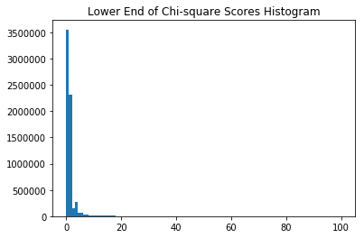

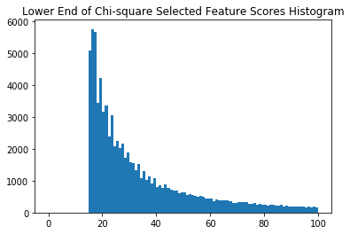

```python
if __name__ == "__main__":

    print("Online Perceptron Classification with Chi-square Feature Selection Preprocessing:\n")
    main('featureSelection')

#==================================================================================
#==================================================================================
```

Feature selection based on the sklearn chi2 function computes the Chi-squared statistics to measure the independence between each feature and the class. The higher the calculated statistics, the lower the p-value, and the more UNLIKELY the feature is independent of the class label. Setting a threshold on the upper bound of the p-values, I get the most relevant n (n << 6,680,976) features to the classification, which will greatly accelerate the training process of Online Perceptron. For example, let ch2_selector_pvalues < 1e-4, the dimensionality of the feature matrix is reduced to 1,000,000 by 101040, consequently, the training time is shortened to about 5 minutes, and the test error rate (9.77%) is pretty good.

Compared with the Mini-Batch approach, although the Chi-square based feature selection does enhance the computational efficiency of the Online Perceptron classifier in our case, neither the feature names with the top and bottom 50 chi-square test scores, nor those with the highest and lowest 50 final weights offer a good intuitive explanation of why the selected or abandoned features should or should not work well for the classification.

## V CONCLUSION

In terms model interpretability, the Mini-Batch based classifier does much better than the Chi-square feature-selection one, and its final weight vector actually provides a good feature importance measure: weights with large absolute values correspond to very positive or negative comments, which naturally implies a +1 or -1 class label. On the contrary, the weight-to-feature mapping after the Chi-square based feature selection processing is intuitively hard to explain from the classification point of view.

## REFERENCE

1. Scikit-learn: Machine Learning in Python, Pedregosa et al., JMLR 12, pp. 2825-2830, 2011.
2. API design for machine learning software: experiences from the scikit-learn project, Buitinck et al., 2013.
3. Wes McKinney. Data Structures for Statistical Computing in Python, Proceedings of the 9th Python in Science Conference, 51-56 (2010) (publisher link)
4. Stéfan van der Walt, S. Chris Colbert and Gaël Varoquaux. The NumPy Array: A Structure for Efficient Numerical Computation, Computing in Science & Engineering, 13, 22-30 (2011), DOI:10.1109/MCSE.2011.37 (publisher link)